# Multi Task Transfer Learning using PyTorch / FastAi

Multi task learning is when a model is trying to learn multiple things at the same time, for example a computer vision model trying to `segment` the image into different regions, `finding bounding boxes` of the objects detected and also `classifying` the objects detected in the image. All this in one go. Simultanously.

More technically...

- Multi-task learning (MTL) is a subfield of machine learning in which multiple learning tasks are solved at the same time, while exploiting commonalities and differences across tasks.
- This can result in improved learning efficiency and prediction accuracy for the task-specific models, when compared to training the models separately
- In the context of Deep Learning, multi-task learning is typically done with either hard or soft parameter sharing of hidden layers.[RUDER](https://ruder.io/multi-task/)
1. **Hard Parameter Sharing**
   - In hard parameter sharing we usually have a number of shared layers which learn the common patterns/features and then for each task we have a custom `head` attached to these shared layers
   - This type of parameter sharing has an added advantage of acting as an regularization effect. This is because now the model is trying to be good at multiple things at the same time and therefore has to generalize better.

[figure not shown]

1. **Soft Parameter Sharing**
   - In soft parameter sharing on the other hand, each task has its own model with its own parameters. The distance between the parameters of the model is then regularized in order to encourage the parameters to be similar. [RUDER](https://ruder.io/multi-task/)

[figure not shown]

In this notebook we try to solve [this](https://github.com/unccv/deep_learning_for_computer_vision/tree/master/challenge) problem.

Goal is to solve 3 different problems simultaneously:

- classification, detection, and segmentation.

The dataset includes ~1000 images including classification, bounding box, and segmentation labels. Importantly, each image only contains one brick, ball or cylinder.

## Approach

Our approach is going to be

1. Load the data using FastAi
2. Build a model using Transfer learning
3. Build our custom heads for `hard parameter` sharing MLT model.

## Expected Learning Outcomes

Learning outcome here should be

1. How to do transfer learning
2. Combining loss functions for multiple tasks
3. Hyper Parameter tuning and custom head design

### Let's get started

Lets first download the helper code from [here](https://github.com/unccv/deep_learning_for_computer_vision) that will download the dataset for us

```python
!git clone https://github.com/unccv/deep_learning_for_computer_vision
```

```
Cloning into 'deep_learning_for_computer_vision'...
remote: Enumerating objects: 96, done.
remote: Counting objects: 100% (96/96), done.
remote: Compressing objects: 100% (69/69), done.
remote: Total 397 (delta 51), reused 58 (delta 25), pack-reused 301
Receiving objects: 100% (397/397), 222.85 MiB | 44.83 MiB/s, done.
Resolving deltas: 100% (171/171), done.
```

Installing required package

```python
!pip install wget
```

```python
%cd /content/deep_learning_for_computer_vision/
```

```
/content/deep_learning_for_computer_vision
```

Downloading the dataset.

```python
from util.get_and_unpack import get_and_unpack
```

```python
url = "http://www.welchlabs.io/unccv/deep_learning/bbc_train.zip"
get_and_unpack(url)
```

```
 Downloading...this might take a little while...

 Unzipping...
Done!
```

### Loading the data

Now that we have downloading the dataset. Let us import it using `fastai` data loader.

Here we leverage the `SegmentationItemList` because

1. This allows us to load the segmentation mask images
2. From the segmentation mask it is easy to extract the `class labels` and also the `bounding boxes` (will see how later)

```python
from fastai.vision import *
from pathlib import Path
```

```python
import fastai
fastai.__version__
```

```
'1.0.61'
```

```python
import torchvision.transforms as T
```

```python
data_path = "/content/deep_learning_for_computer_vision/bbc_train"
im_size=(256,256)
classes = array(['background', 'brick', 'ball', 'cylinder'])
batch_size = 16

path = Path(data_path)

def get_y_fn(x): return path/'masks'/(x.stem + '.png')

src = (SegmentationItemList.from_folder(path/'images')
       .split_by_rand_pct(0.3)
       .label_from_func(get_y_fn, classes=classes))

#Don't normalize data here - assume normalization happens inside of Model.
data = src.transform(get_transforms(max_rotate=45 , flip_vert=True , max_zoom=1), tfm_y=True, size=im_size).databunch(bs=batch_size)

data = data.normalize(imagenet_stats)
#x,y = data.one_batch()
data
```

```
ImageDataBunch;

Train: LabelList (660 items)
x: SegmentationItemList
Image (3, 256, 256),Image (3, 256, 256),Image (3, 256, 256),Image (3, 256, 256),Image (3, 256, 256)
y: SegmentationLabelList
ImageSegment (1, 256, 256),ImageSegment (1, 256, 256),ImageSegment (1, 256, 256),ImageSegment (1, 256, 256),ImageSegment (1, 256, 256)
Path: /content/deep_learning_for_computer_vision/bbc_train/images;

Valid: LabelList (282 items)
x: SegmentationItemList
Image (3, 256, 256),Image (3, 256, 256),Image (3, 256, 256),Image (3, 256, 256),Image (3, 256, 256)
y: SegmentationLabelList
ImageSegment (1, 256, 256),ImageSegment (1, 256, 256),ImageSegment (1, 256, 256),ImageSegment (1, 256, 256),ImageSegment (1, 256, 256)
Path: /content/deep_learning_for_computer_vision/bbc_train/images;

Test: None
```

## NOTE

One crucial thing to note here is that whenever we plan to use `transfer learning`, we have to keep in mind the assumptions made by the `pretrained` model that we are going to use.

For example ,for `pretrained` models in `pytorch`

> All pre-trained models expect input images normalized in the some way, e.g mini-batches of 3-channel RGB images of shape (3 x H x W), where H and W are expected to be at least 224. The images have to be loaded in to a range of [0, 1] and then normalized using mean = [0.485, 0.456, 0.406] and std = [0.229, 0.224, 0.225].

`FastAi` provides a helper function `data.normalize` that takes in the as parameter the statistics like mean and std to normalize the input images. It also provides variables which have meta information stored for commonly used models like for `ImageNet` in `imagenet_stats` variable.

Therefore in the last line above we normalize the input images as needed.

```python
x,y = data.one_batch()
```

Loading pytorch library

```python
from torch import nn
import torch.nn.functional as F
import torchvision.models as models
device = torch.device("cuda" if torch.cuda.is_available() else "cpu")
device
```

```
device(type='cuda')
```

We create two helper functions one to extract the class labels and one to extract the bounding box from the segmentation mask.( We later encapsulate all the helper functions in a class below, to avoid namespace pollution)

`get_class_labels` - relies on the fact that the `mask` image has only two values 0 and class label. Therefore it looks up the unique values in the image array and picks the first non-zero one.

`get_bboxes` - relies on first and last non-zero entries in the image to get the coordinates of the top left and bottom right points of the bounding box.

```python
def get_class_labels(self,y_true):
    return torch.tensor([torch.unique(y_true[i][y_true[i]!=0])[0] for i in range(y_true.shape[0])] , device=device)

def get_bboxes(self,y_true):
  bboxes=torch.zeros((y_true.shape[0], 4) , device=device)
  for i in range(y_true.shape[0]):
      rows,cols= torch.where(y_true[i, 0]!=0)
      bboxes[i, :] = torch.tensor([rows.min(), cols.min(), rows.max(), cols.max()])
  return bboxes / 256.
```

## Creating the Custom Head.

Now we create our custom head that we will stick on top of [ResNet50](https://arxiv.org/pdf/1512.03385.pdf) model.

Our design for the custom head will have 3 seperate heads , one for each of the task at hand.

1. **Segmentation Head**
   - For segmentation head we use `Convolution Transpose` layer which is the inverse operation of convolution and therefore increases the dimension of the input.
   - The input that this head recives is the output of the `ResNet` base model, which has `2048` channels
   - Then we reduce the number of `channels/filters` down to 4, one for each of the 4 possible segmentation outcomes. (brick , ball , cylinder , backgroun)
   - Key thing here is that we have to keep in mind that our output size is `4x256x256` and therefore we need to setup our `kernel size` , `stride` , `paddings` appropriately

```python
def conv_trans(self,ni, nf, ks = 4, stride = 2, padding = 1):
      return nn.Sequential(
          nn.ConvTranspose2d(ni, nf, kernel_size=ks, bias=False, stride=stride, padding = padding),
          nn.LeakyReLU(inplace = True),
          nn.BatchNorm2d(nf))

segment_model = nn.Sequential(
                            conv_trans(2048, 512,ks=7 , stride=2 , padding=1),
                            nn.Dropout(0.5),
                            conv_trans(512, 256 , ks=7 , stride=2 , padding=4),
                            conv_trans(256, 128, ks=7 , stride=2, padding=6),
                            nn.Dropout(0.5),
                            conv_trans(128, 64, ks=5 , stride=2 , padding=1),
                            conv_trans(64, 32 ,  ks=5 , stride=2 , padding=1),
                            nn.ConvTranspose2d(32, 4, kernel_size=4, bias=False, stride=1, padding = 1)
      )
```

1. **Bounding box head**
   - For bounding box head we `Flatten` the output of the `ResNet` and then pass it through a bunch of `Linear` layers
   - The number of output units is 4, (x-top-left , y-top-left , x-bottom-right , y-bottom-right)

```python
bounding_box_model =  nn.Sequential(
          AdaptiveConcatPool2d((4,4)),
          Flatten(),
          nn.LeakyReLU(),
          nn.Dropout(0.5),
          nn.Linear(2*2048*4*4,256), #2*512*4*4
          nn.LeakyReLU(),
          nn.BatchNorm1d(256),
          nn.Dropout(0.5),
          nn.Linear(256,4)
)
```

1. **Classification head**
   - For classification head, we follow a standard `classifier` design
   - Similar to the bounding box model , we Flatten the `ResNet` CNN output and then pass it through linear layers

```python
classification_model = nn.Sequential(
          AdaptiveConcatPool2d((4,4)),
          Flatten(),
          nn.LeakyReLU(),
          nn.Dropout(0.5),
          nn.Linear(2*2048*4*4,64), #2*512*4*4
          nn.LeakyReLU(),
          nn.BatchNorm1d(64),
          nn.Dropout(0.5),
          nn.Linear(64,4)
      )
```

### Forward method of our MLT

moving the data forward through our network we take the output from resnet and pass it separately to each of the 3 custom heads we have.

```python
def forward(x):
      segment = segment_model(x)
      #print(x.shape)
      bounding_box = bounding_box_model(x)
      classification = classification_model(x)
      return bounding_box , segment , classification
```

Important bit is that we would be returning 3 different outputs and then use each of those in our `custom loss function` to calculate how good or bad we are doing.

### Custom Loss function

Our loss function we will be calculating individual losses for each of our tasks.

1. For classification its straightforward that we use `Cross Entropy`
2. For regression/bounding box, we can use `MSE` or `L1` loss
3. For segmentation, there are many segmentation specific loss functions. A good survey is [here](https://neptune.ai/blog/image-segmentation-in-2020). But since we are outputing 4 channels in our segment model, one for each of the class, we can also use `Cross Entropy` as well.

**BUT how do we combine all these individual losses ?**

Now this is the challenging bit, one option is to introduce more hyperparameters that weight each loss and then we simply combine/add them together to get a total loss.

There are other more sophisticated [approaches](https://www.kdnuggets.com/2019/02/deep-multi-task-learning.html) but lets go for simple weighted combination.

```python
def my_loss_function(y_pred,y_true):
    class_labels = get_class_labels(y_true)
    #print(class_labels)
    bboxes =  get_bboxes(y_true)

    mseloss = nn.SmoothL1Loss()
    cel1 = nn.CrossEntropyLoss(weight=torch.tensor([0.1,1,1,1] , device=device))
    cel2 = nn.CrossEntropyLoss(weight=torch.tensor([0.3,1,1,1] , device=device))

    class_loss  =cel1(y_pred[2] , class_labels)
    bb_loss = mseloss(y_pred[0] , bboxes )
    segment_loss = cel2( y_pred[1] , y_true.squeeze(1) )


    #class_loss = 0
    #bb_loss = 0
    total_loss = torch.div(5*segment_loss + 5*class_loss + 15*bb_loss , 25)
    print(f"class_loss : {class_loss} , bb_loss: {bb_loss} , segment_loss : {segment_loss} ,  total loss {total_loss}")
    return total_loss
```

Lets just encapsulate everything inside a `Helpers` class

```python
class Helpers:

  class CustomHead(nn.Module):
    def __init__(self , height , width):
      super(Helpers.CustomHead, self).__init__()

      self.segment_model = nn.Sequential(
                            self.conv_trans(2048, 512,ks=7 , stride=2 , padding=1),
                            nn.Dropout(0.5),
                            self.conv_trans(512, 256 , ks=7 , stride=2 , padding=4),
                            self.conv_trans(256, 128, ks=7 , stride=2, padding=6),
                            nn.Dropout(0.5),
                            self.conv_trans(128, 64, ks=5 , stride=2 , padding=1),
                            self.conv_trans(64, 32 ,  ks=5 , stride=2 , padding=1),
                            nn.ConvTranspose2d(32, 4, kernel_size=4, bias=False, stride=1, padding = 1)
      )

      self.bounding_box_model =  nn.Sequential(
          AdaptiveConcatPool2d((4,4)),
          Flatten(),
          nn.LeakyReLU(),
          nn.Dropout(0.5),
          nn.Linear(2*2048*4*4,256), #2*512*4*4
          nn.LeakyReLU(),
          nn.BatchNorm1d(256),
          nn.Dropout(0.5),
          nn.Linear(256,4)
      )

      self.classification_model = nn.Sequential(
          AdaptiveConcatPool2d((4,4)),
          Flatten(),
          nn.LeakyReLU(),
          nn.Dropout(0.5),
          nn.Linear(2*2048*4*4,64), #2*512*4*4
          nn.LeakyReLU(),
          nn.BatchNorm1d(64),
          nn.Dropout(0.5),
          nn.Linear(64,4)
      )

    def forward(self, x):
      segment = self.segment_model(x)
      #print(x.shape)
      bounding_box = self.bounding_box_model(x)
      classification = self.classification_model(x)
      return bounding_box , segment , classification


    def conv_trans(self,ni, nf, ks = 4, stride = 2, padding = 1):
      return nn.Sequential(
          nn.ConvTranspose2d(ni, nf, kernel_size=ks, bias=False, stride=stride, padding = padding),
          nn.LeakyReLU(inplace = True),
          nn.BatchNorm2d(nf))

  def get_class_labels(self,y_true):
    return torch.tensor([torch.unique(y_true[i][y_true[i]!=0])[0] for i in range(y_true.shape[0])] , device=device)

  def get_bboxes(self,y_true):
    bboxes=torch.zeros((y_true.shape[0], 4) , device=device)
    for i in range(y_true.shape[0]):
        rows,cols= torch.where(y_true[i, 0]!=0)
        bboxes[i, :] = torch.tensor([rows.min(), cols.min(), rows.max(), cols.max()])
    return bboxes / 256.

  def my_loss_function(self,y_pred,y_true):
    class_labels = self.get_class_labels(y_true)
    #print(class_labels)
    bboxes =  self.get_bboxes(y_true)

    mseloss = nn.SmoothL1Loss()
    cel1 = nn.CrossEntropyLoss(weight=torch.tensor([0.1,1,1,1] , device=device))
    cel2 = nn.CrossEntropyLoss(weight=torch.tensor([0.3,1,1,1] , device=device))

    class_loss  =cel1(y_pred[2] , class_labels)
    bb_loss = mseloss(y_pred[0] , bboxes )
    segment_loss = cel2( y_pred[1] , y_true.squeeze(1) )


    #class_loss = 0
    #bb_loss = 0
    total_loss = torch.div(5*segment_loss + 5*class_loss + 15*bb_loss , 25)
    print(f"class_loss : {class_loss} , bb_loss: {bb_loss} , segment_loss : {segment_loss} ,  total loss {total_loss}")
    return total_loss

  def pixel_accuracy(self,y_pred, y_true):
    y_=y_true.squeeze(dim=1)
    yhat_=y_pred[1].argmax(dim=1)
    return (y_==yhat_).sum().float()/y_true.numel()

  def pixel_recall(self, y_pred , y_true):
    y_=y_true.squeeze(dim=1)
    yhat_=y_pred[1].argmax(dim=1)
    return (y_[yhat_ > 0]==yhat_[yhat_ > 0]).sum().float()/y_[y_ > 0].numel()
```

Lets create our custom head

```python
custom_head = Helpers.CustomHead(*im_size)
```

Now we leverage `fastai` to do transfer learning use `resnet-50` as the base model. We pass our custom loss function to the `cnn_learner` along with some metrics for `segmentation` performance.

```python
learn=cnn_learner(data
                  , models.resnet50
                  , custom_head=custom_head
                  ,loss_func=Helpers().my_loss_function
                  , metrics=[Helpers().pixel_accuracy , Helpers().pixel_recall])
```

Let's first find a good learning rate

```python
learn.freeze()
```

```python
learn.lr_find()
```

66.67% [2/3 00:46<00:23]

| epoch | train_loss | valid_loss | pixel_accuracy | pixel_recall | time |
| --- | --- | --- | --- | --- | --- |
| 0 | 2.073473 | #na# | 00:24 |  |  |
| 1 | 1.455733 | #na# | 00:22 |  |  |

19.51% [8/41 00:05<00:20 5.6341]

```
class_loss : 2.4294326305389404 , bb_loss: 1.1379821300506592 , segment_loss : 4.517766952514648 ,  total loss 2.0722291469573975
class_loss : 2.099644660949707 , bb_loss: 1.2599678039550781 , segment_loss : 4.557870388031006 ,  total loss 2.0874836444854736
class_loss : 2.124520778656006 , bb_loss: 1.3920496702194214 , segment_loss : 4.497938632965088 ,  total loss 2.159721612930298
```

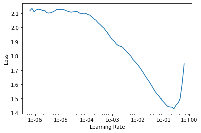

```python
learn.recorder.plot()
```

Lets be a bit aggresive and pick `1e-2` as the learning rate

```python
lr=1e-2
#learn.unfreeze()
learn.fit_one_cycle(20, slice(lr/10, lr))
```

| epoch | train_loss | valid_loss | pixel_accuracy | pixel_recall | time |
| --- | --- | --- | --- | --- | --- |
| 0 | 1.405092 | 0.946821 | 0.881591 | 0.023084 | 00:28 |
| 1 | 0.950905 | 0.371786 | 0.947538 | 0.396784 | 00:27 |
| 2 | 0.629880 | 0.225249 | 0.951267 | 0.479188 | 00:26 |
| 3 | 0.405276 | 0.086299 | 0.939907 | 0.668745 | 00:27 |
| 4 | 0.257588 | 0.099285 | 0.947233 | 0.840900 | 00:27 |
| 5 | 0.159639 | 0.050746 | 0.961345 | 0.930345 | 00:27 |
| 6 | 0.113265 | 0.045899 | 0.941303 | 0.930732 | 00:27 |
| 7 | 0.088099 | 0.034671 | 0.976445 | 0.885543 | 00:27 |
| 8 | 0.067789 | 0.023640 | 0.975780 | 0.924917 | 00:27 |
| 9 | 0.053608 | 0.021602 | 0.971057 | 0.966193 | 00:27 |
| 10 | 0.045253 | 0.019206 | 0.976244 | 0.931784 | 00:27 |
| 11 | 0.043476 | 0.021068 | 0.976043 | 0.942183 | 00:27 |
| 12 | 0.036214 | 0.016201 | 0.983517 | 0.911108 | 00:27 |
| 13 | 0.035145 | 0.018388 | 0.982513 | 0.900367 | 00:27 |
| 14 | 0.033635 | 0.015736 | 0.979366 | 0.948607 | 00:27 |
| 15 | 0.032661 | 0.014370 | 0.984188 | 0.928108 | 00:27 |
| 16 | 0.026703 | 0.013514 | 0.981231 | 0.954598 | 00:27 |
| 17 | 0.024836 | 0.013188 | 0.981929 | 0.952113 | 00:27 |
| 18 | 0.022674 | 0.013089 | 0.981778 | 0.956766 | 00:27 |
| 19 | 0.021475 | 0.012774 | 0.981877 | 0.957017 | 00:27 |

```
class_loss : 1.9390373229980469 , bb_loss: 1.0602967739105225 , segment_loss : 4.483863353729248 ,  total loss 1.9207580089569092
class_loss : 2.773181915283203 , bb_loss: 1.6291701793670654 , segment_loss : 4.273028373718262 ,  total loss 2.386744260787964
class_loss : 1.737779140472412 , bb_loss: 1.4650237560272217 , segment_loss : 3.883405923843384 ,  total loss 2.003251314163208
class_loss : 1.1841117143630981 , bb_loss: 1.5871374607086182 , segment_loss : 3.6510632038116455 ,  total loss 1.9193174839019775
class_loss : 3.1869897842407227 , bb_loss: 1.4089980125427246 , segment_loss : 3.2167446613311768 ,  total loss 2.126145601272583
class_loss : 2.0858592987060547 , bb_loss: 1.478468894958496 , segment_loss : 2.980173110961914 ,  total loss 1.9002877473831177
class_loss : 0.0003166601527482271 , bb_loss: 0.0005959706613793969 , segment_loss : 0.044550709426403046 ,  total loss 0.009331056848168373
```

We see that within 20 epochs we have gone to 98% pixel accuracy and 95% pixel recall (finding actual object and not just background)

Lets fine tune the entire model, including the base `resnet-50` model. For that we `unfreeze` all the weights and look for a good learning rate

```python
learn.unfreeze()
learn.lr_find()
```

33.33% [1/3 00:25<00:50]

| epoch | train_loss | valid_loss | pixel_accuracy | pixel_recall | time |
| --- | --- | --- | --- | --- | --- |
| 0 | 0.022408 | #na# | 00:25 |  |  |

29.27% [12/41 00:07<00:19 0.0574]

```
class_loss : 0.027950717136263847 , bb_loss: 0.0032590015325695276 , segment_loss : 0.051369763910770416 ,  total loss 0.017819495871663094
class_loss : 0.013831938616931438 , bb_loss: 0.003494837787002325 , segment_loss : 0.06011051684617996 ,  total loss 0.016885392367839813
class_loss : 0.037993013858795166 , bb_loss: 0.0025363611057400703 , segment_loss : 0.05405757203698158 ,  total loss 0.019931932911276817
class_loss : 0.0022425956558436155 , bb_loss: 0.0037597287446260452 , segment_loss : 0.05357205867767334 ,  total loss 0.013418767601251602
LR Finder is complete, type {learner_name}.recorder.plot() to see the graph.
```

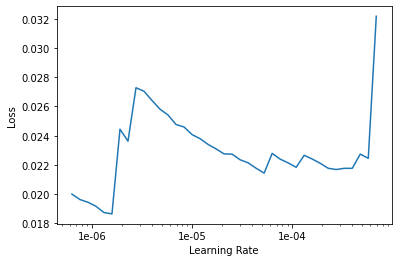

```python
learn.recorder.plot()
```

Picking `5e-05` as the learning rate

```python
lr = 5e-05
learn.fit_one_cycle(8 , slice(lr/10, lr))
```

| epoch | train_loss | valid_loss | pixel_accuracy | pixel_recall | time |
| --- | --- | --- | --- | --- | --- |
| 0 | 0.024553 | 0.012751 | 0.981594 | 0.959619 | 00:29 |
| 1 | 0.022172 | 0.012705 | 0.981936 | 0.958185 | 00:29 |
| 2 | 0.023615 | 0.012418 | 0.982468 | 0.957186 | 00:29 |
| 3 | 0.020552 | 0.011874 | 0.982160 | 0.962092 | 00:29 |
| 4 | 0.021348 | 0.012189 | 0.983307 | 0.954144 | 00:29 |
| 5 | 0.020796 | 0.012095 | 0.982010 | 0.960559 | 00:29 |
| 6 | 0.020097 | 0.012164 | 0.982653 | 0.956841 | 00:29 |
| 7 | 0.018086 | 0.011855 | 0.983854 | 0.951342 | 00:29 |

```
class_loss : 0.002826165407896042 , bb_loss: 0.002107048872858286 , segment_loss : 0.05538589134812355 ,  total loss 0.012906640768051147
class_loss : 0.0008093640790320933 , bb_loss: 0.005108487792313099 , segment_loss : 0.07397111505270004 ,  total loss 0.01802118867635727
class_loss : 0.0015624173684045672 , bb_loss: 0.002138481941074133 , segment_loss : 0.06253179162740707 ,  total loss 0.014101930893957615
class_loss : 0.001619656221009791 , bb_loss: 0.0020663971081376076 , segment_loss : 0.06825495511293411 ,  total loss 0.015214759856462479
class_loss : 0.005510393064469099 , bb_loss: 0.0033751926384866238 , segment_loss : 0.06407054513692856 ,  total loss 0.015941303223371506
class_loss : 0.001345532014966011 , bb_loss: 0.0017254312988370657 , segment_loss : 0.05141229182481766 ,  total loss 0.011586823500692844
class_loss : 0.00039891499909572303 , bb_loss: 0.0005638169241137803 , segment_loss : 0.03584339842200279 ,  total loss 0.007586752995848656
class_loss : 0.00019355796393938363 , bb_loss: 0.0005149262142367661 , segment_loss : 0.04214199259877205 ,  total loss 0.008776065893471241
```

We get only marginal improvements. Therefore lets just look at the results we have visually.

```python
bounding , segment , classification = learn.model(x.cuda())
```

Looking at bounding boxes

```python
bounding[0]
```

```
tensor([0.3414, 0.3820, 0.6143, 0.6253], device='cuda:0',
       grad_fn=<SelectBackward>)
```

```python
Helpers().get_bboxes(y)[0]
```

```
tensor([0.4062, 0.3984, 0.5469, 0.4844], device='cuda:0')
```

Looking at classification

```python
torch.argmax(classification[2])
```

```
tensor(1, device='cuda:0')
```

```python
Helpers().get_class_labels(y)[2]
```

```
tensor(1, device='cuda:0')
```

Lets look at the segmentation

```python
import matplotlib.pyplot as plt
```

[figure not shown]

```python
plt.imshow(np.moveaxis(x[5].detach().numpy(), 0 , 2))
```

```python
segment.shape
```

```
torch.Size([16, 4, 256, 256])
```

```python
segment[5]
```

[output not shown]

```python
torch.argmax(segment[6] , 0).cpu().detach().numpy()
```

```
array([[0, 0, 0, 0, ..., 0, 0, 0, 0],
       [0, 0, 0, 0, ..., 0, 0, 0, 0],
       [0, 0, 0, 0, ..., 0, 0, 0, 0],
       [0, 0, 0, 0, ..., 0, 0, 0, 0],
       ...,
       [0, 0, 0, 0, ..., 0, 0, 0, 0],
       [0, 0, 0, 0, ..., 0, 0, 0, 0],
       [0, 0, 0, 0, ..., 0, 0, 0, 0],
       [0, 0, 0, 0, ..., 0, 0, 0, 0]])
```

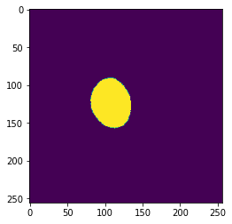

```python
plt.imshow(torch.argmax(segment[6] , 0).cpu().detach().numpy())
```

```python
y.shape
```

```
torch.Size([16, 1, 256, 256])
```

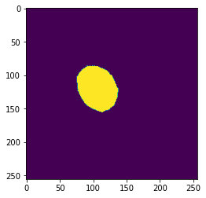

```python
plt.imshow(y[6][0].detach().numpy())
```

We see that we did a good enough job on all 3 tasks by just learning a single model with multiple heads.

Now we can more quantitatively evaluate the model.

```python
learn.export("/content/deep_learning_for_computer_vision/sample_models/export2.pkl")
```

```python
from fastai.vision import load_learner, normalize, torch
import numpy as np

class Model(object):
    def __init__(self, path='../sample_models', file='export.pkl'):

        self.learn=load_learner(path=path, file=file) #Load model
        self.class_names=['brick', 'ball', 'cylinder'] #Be careful here, labeled data uses this order, but fastai will use alphabetical by default!

    def predict(self, x):
        '''
        Input: x = block of input images, stored as Torch.Tensor of dimension (batch_sizex3xHxW),
                   scaled between 0 and 1.
        Returns: a tuple containing:
            1. The final class predictions for each image (brick, ball, or cylinder) as a list of strings.
            2. Upper left and lower right bounding box coordinates (in pixels) for the brick ball
            or cylinder in each image, as a 2d numpy array of dimension batch_size x 4.
            3. Segmentation mask for the image, as a 3d numpy array of dimension (batch_sizexHxW). Each value
            in each segmentation mask should be either 0, 1, 2, or 3. Where 0=background, 1=brick,
            2=ball, 3=cylinder.
        '''

        #Normalize input data using the same mean and std used in training:
        x_norm=normalize(x, torch.tensor(self.learn.data.stats[0]),
                            torch.tensor(self.learn.data.stats[1]))


        #Pass data into model:
        device = torch.device('cuda' if torch.cuda.is_available() else 'cpu')
        with torch.no_grad():
            bounding , segment , classification =self.learn.model(x_norm.to(device))
            #print(bounding , segment)
            bounding = bounding.detach().cpu().numpy()
            segment = segment.detach().cpu().numpy()
            classification = classification.detach().cpu().numpy()

        #Post-processing/parsing outputs, here's an example for classification only:
        class_prediction_indices= np.argmax(classification , 1)
        class_predictions=[self.learn.data.classes[i] for i in class_prediction_indices]

        return (class_predictions, bounding*256., np.argmax(segment, 1))
```

```python
## ---------------------------- ##
##
## eval.py
## Deep learning programming challenge evaluation code.
##
## ---------------------------- ##

import numpy as np
import time
from fastai.vision import *
from pathlib import Path

def evaluate(data_path='../data/bbc_train',
             model_dir = '../sample_models',
             batch_size=64,
             im_size=(256,256)):


    print("1. Loading Data...")

    path=Path(data_path)
    def get_y_fn(x): return path/'masks'/(x.stem + '.png')
    classes = array(['background', 'brick', 'ball', 'cylinder'])

    src = (SegmentationItemList.from_folder(path/'images')
       .split_by_rand_pct(0.0)
       .label_from_func(get_y_fn, classes=classes))

    #Don't normalize data here - assume normalization happens inside of Model.
    data = src.transform(get_transforms(), tfm_y=True, size=im_size).databunch(bs=batch_size)
    print(data)


    print("2. Instantiating Model...")
    M = Model(path=model_dir, file='export2.pkl')


    print("3. Evaluating on Test Images...")
    round_metric = []
    for i in range(5):
      x,y = data.one_batch()
      #Extract class label from mask:
      class_labels=np.array([np.unique(y[i][y[i]!=0])[0] for i in range(x.shape[0])])

      #Extract bounding box from mask:
      bboxes=np.zeros((x.shape[0], 4))
      for i in range(x.shape[0]):
          rows,cols= np.where(y[i, 0]!=0)
          bboxes[i, :] = np.array([rows.min(), cols.min(), rows.max(), cols.max()])

      preds=M.predict(x)

      classification_accuracy=(np.array([data.classes[i] for i in class_labels])==np.array(preds[0])).sum()/len(preds[0])
      bbox_score = 1 - np.mean(np.abs(bboxes-preds[1]))/(x.shape[-1]) #Divide by image height to rougly normalize score
      segmentation_accuracy=float((preds[2] == np.array(y.squeeze(1))).sum())/y.numel()
      combined_accuracy=np.mean([classification_accuracy, bbox_score, segmentation_accuracy])
      round_metric.append([combined_accuracy, classification_accuracy, bbox_score, segmentation_accuracy])

    return np.min(round_metric , 1)


def calculate_score(combined_accuracy):
    if combined_accuracy >= 0.99: score = 10
    elif combined_accuracy >= 0.98: score = 9
    elif combined_accuracy >= 0.97: score = 8
    elif combined_accuracy >= 0.96: score = 7
    elif combined_accuracy >= 0.95: score = 6
    elif combined_accuracy >= 0.90: score = 5
    else: score = 4
    return score
```

```python
evaluate("./bbc_train" , "./sample_models")
```

```
1. Loading Data...
ImageDataBunch;

Train: LabelList (942 items)
x: SegmentationItemList
Image (3, 256, 256),Image (3, 256, 256),Image (3, 256, 256),Image (3, 256, 256),Image (3, 256, 256)
y: SegmentationLabelList
ImageSegment (1, 256, 256),ImageSegment (1, 256, 256),ImageSegment (1, 256, 256),ImageSegment (1, 256, 256),ImageSegment (1, 256, 256)
Path: bbc_train/images;

Valid: LabelList (0 items)
x: SegmentationItemList

y: SegmentationLabelList

Path: bbc_train/images;

Test: None
2. Instantiating Model...
3. Evaluating on Test Images...
```

```
array([0.969322, 0.966199, 0.964498, 0.963493, 0.970602])
```

We get overall `minimum`accuracy across 5 batchs of around 96% on each of the task.

Now we can save the model to google drive if needed.

```python
from google.colab import drive
drive.mount('/content/gdrive')
```

```python
%ls /content/gdrive/MyDrive
```

```python
%cp ./sample_models/export2.pkl /content/gdrive/MyDrive/CVSubmission/export_97.pkl
```